# hw04_jrhaag2

Jeffery Haag

10/3/2020

## Exercise 1 (Using `lm` for Inference)

**(a)**

```r
faithful_model = lm(eruptions ~ waiting, data = faithful)
# plot(eruptions ~ waiting, data = faithful)
# abline(faithfulModel1, lwd = 3)
summary(faithful_model)
```

```
##
## Call:
## lm(formula = eruptions ~ waiting, data = faithful)
##
## Residuals:
##      Min       1Q   Median       3Q      Max
## -1.29917 -0.37689  0.03508  0.34909  1.19329
##
## Coefficients:
##              Estimate Std. Error t value Pr(>|t|)
## (Intercept) -1.874016   0.160143  -11.70   <2e-16 ***
## waiting      0.075628   0.002219   34.09   <2e-16 ***
## ---
## Signif. codes:  0 '***' 0.001 '**' 0.01 '*' 0.05 '.' 0.1 ' ' 1
##
## Residual standard error: 0.4965 on 270 degrees of freedom
## Multiple R-squared:  0.8115, Adjusted R-squared:  0.8108
## F-statistic:  1162 on 1 and 270 DF,  p-value: < 2.2e-16
```

The null hypothesis is that B1 = 0 and alternative hypothesis is B1 != 0. The test statistic is 34.09. P value is p < 2.2e-16 . We reject the null at alpha =0.01. The wait time is a signifigant factor of eruption time for old faithful geyser. They are almost ceartainly related.

**(b)**

```r
confidence_rad = 0.01*.4965
confint(faithful_model, level=0.99)
```

```
##                  0.5 %     99.5 %
## (Intercept) -2.2894534 -1.4585785
## waiting      0.0698727  0.0813832
```

```r
confidence_rad
```

```
## [1] 0.004965
```

The confidence interval is 0.0698727 to 0.0813832. This means that we are 99% confident that for an increaase of 1 minute wait time the eruption will increase withing that range above. Also it doesnt include zero so we can reject the null at 99%.

**(c)**

```r
confint(faithful_model, level=0.9)
```

```
##                     5 %        95 %
## (Intercept) -2.13833519 -1.60969678
## waiting      0.07196621  0.07928969
```

```r
confidence_rad
```

```
## [1] 0.004965
```

The confidence interval is -2.13833519 -1.60969678. This means that we are 90% confident that at wait time zero we expect a negative eruption time within the above range. Since this range doesn’t include 0 we can reject the null at 90%.

**(d)**

```r
wait_times = data.frame(waiting = c(75,80))
predict(faithful_model, newdata = wait_times, interval = c("confidence"), level = 0.95)
```

```
##       fit      lwr      upr
## 1 3.79808 3.736159 3.860002
## 2 4.17622 4.104848 4.247592
```

THe interval for 75 is 3.736159 to 3.860002 with mean 3.79808 and for 80 is 4.104848 to 4.247592 with mean 4.17622. The range for 80 is bigger because it is farther away from the norm so we are less ceartain. The expexted error is bigger and our interval scales off that.

**(e)**

```r
wait_times_e = data.frame(waiting = c(75,100))
predict(faithful_model, newdata = wait_times_e, interval = c("prediction"), level = 0.95)
```

```
##        fit      lwr      upr
## 1 3.798080 2.818592 4.777569
## 2 5.688779 4.701239 6.676319
```

For 75 the eruption will be 2.818592 to 4.777569 minutes and for 100 it will be 4.701239 to 6.676319 minutes.

**(f)**

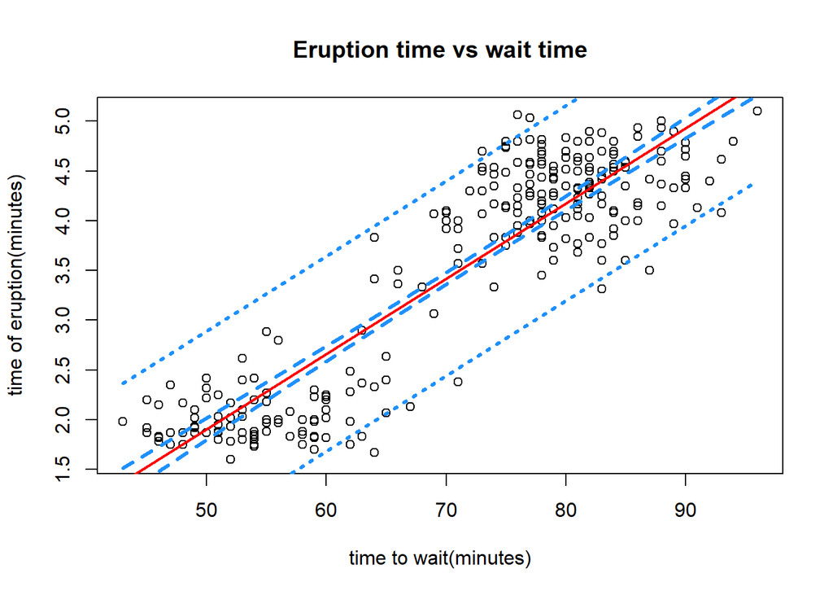

```r
wait_times_f = seq(min(faithful$waiting), max(faithful$waiting), by = 0.01)
faithful_rad = predict(faithful_model, newdata = data.frame(waiting = wait_times_f),
                       interval = ("confidence"), level = 0.95)

faithful_rad2 = predict(faithful_model, newdata = data.frame(waiting = wait_times_f), interval = c("prediction"), level = 0.95)

plot(eruptions ~ waiting, data = faithful,
     xlab = "time to wait(minutes)",
     ylab = "time of eruption(minutes)",
     main = "Eruption time vs wait time")
abline(faithful_model, lwd = 2, col = "red")

lines(wait_times_f, faithful_rad[,"lwr"], col = "dodgerblue", lwd = 3, lty = 2)
lines(wait_times_f, faithful_rad[,"upr"], col = "dodgerblue", lwd = 3, lty = 2)
lines(wait_times_f, faithful_rad2[,"lwr"], col = "dodgerblue", lwd = 3, lty = 3)
lines(wait_times_f, faithful_rad2[,"upr"], col = "dodgerblue", lwd = 3, lty = 3)
```

## Exercise 2 (Using `lm` for Inference)

**(a)**

```r
library(faraway)
cholesterol_model = lm(chol ~ weight, data = diabetes)

summary(cholesterol_model)
```

```
##
## Call:
## lm(formula = chol ~ weight, data = diabetes)
##
## Residuals:
##     Min      1Q  Median      3Q     Max
## -125.75  -29.50   -3.24   22.62  230.71
##
## Coefficients:
##              Estimate Std. Error t value Pr(>|t|)
## (Intercept) 194.98642   10.02215  19.456   <2e-16 ***
## weight        0.07363    0.05499   1.339    0.181
## ---
## Signif. codes:  0 '***' 0.001 '**' 0.01 '*' 0.05 '.' 0.1 ' ' 1
##
## Residual standard error: 44.21 on 399 degrees of freedom
##   (2 observations deleted due to missingness)
## Multiple R-squared:  0.004474,   Adjusted R-squared:  0.001979
## F-statistic: 1.793 on 1 and 399 DF,  p-value: 0.1813
```

```r
print("Anova Table")
```

```
## [1] "Anova Table"
```

```r
anova(cholesterol_model)
```

```
## Analysis of Variance Table
##
## Response: chol
##            Df Sum Sq Mean Sq F value Pr(>F)
## weight      1   3505  3505.4  1.7932 0.1813
## Residuals 399 779991  1954.9
```

THe null hypotheses is that B1 = 0. Alternative is B1 doesn’t = 0. The test statistic is 1.793. The p value is .1813. We cannot reject the null at alpha=0.05. From this we cannot say that weight and cholesterol are significantly related to each other.

**(b)**

```r
library(faraway)
cholesterol_model2 = lm(hdl ~ weight, data = diabetes)

summary(cholesterol_model2)
```

```
##
## Call:
## lm(formula = hdl ~ weight, data = diabetes)
##
## Residuals:
##     Min      1Q  Median      3Q     Max
## -45.829 -10.455  -3.330   8.421  69.670
##
## Coefficients:
##             Estimate Std. Error t value Pr(>|t|)
## (Intercept) 72.70233    3.74976  19.389  < 2e-16 ***
## weight      -0.12499    0.02057  -6.075 2.89e-09 ***
## ---
## Signif. codes:  0 '***' 0.001 '**' 0.01 '*' 0.05 '.' 0.1 ' ' 1
##
## Residual standard error: 16.54 on 399 degrees of freedom
##   (2 observations deleted due to missingness)
## Multiple R-squared:  0.08467,    Adjusted R-squared:  0.08238
## F-statistic: 36.91 on 1 and 399 DF,  p-value: 2.891e-09
```

```r
print("Anova Table")
```

```
## [1] "Anova Table"
```

```r
anova(cholesterol_model2)
```

```
## Analysis of Variance Table
##
## Response: hdl
##            Df Sum Sq Mean Sq F value    Pr(>F)
## weight      1  10100 10100.2  36.909 2.891e-09 ***
## Residuals 399 109188   273.7
## ---
## Signif. codes:  0 '***' 0.001 '**' 0.01 '*' 0.05 '.' 0.1 ' ' 1
```

THe null hypotheses is that B1 = 0. Alternative is B1 doesn’t = 0. The test statistic is 36.91 The p value is 2.891e-09 We can reject the null at alpha=0.05. From this we can confidently say that weight and HDL cholesterol are significantly related to each other.

## Exercise 3 (Inference “without” `lm`)

```r
goalies = read.csv("goalies.csv")
goalie_model = lm(W ~ MIN, data = goalies)

summary(goalie_model)
```

```
##
## Call:
## lm(formula = W ~ MIN, data = goalies)
##
## Residuals:
##     Min      1Q  Median      3Q     Max
## -81.814  -4.447   2.691   4.316 111.354
##
## Coefficients:
##               Estimate Std. Error t value Pr(>|t|)
## (Intercept) -4.402e+00  7.698e-01  -5.719 1.58e-08 ***
## MIN          7.846e-03  5.071e-05 154.724  < 2e-16 ***
## ---
## Signif. codes:  0 '***' 0.001 '**' 0.01 '*' 0.05 '.' 0.1 ' ' 1
##
## Residual standard error: 16.78 on 711 degrees of freedom
##   (3 observations deleted due to missingness)
## Multiple R-squared:  0.9712, Adjusted R-squared:  0.9711
## F-statistic: 2.394e+04 on 1 and 711 DF,  p-value: < 2.2e-16
```

```r
estimate = 7.846e-03;
std_err = 5.071e-05;
estimate;
```

```
## [1] 0.007846
```

```r
std_err;
```

```
## [1] 5.071e-05
```

```r
n = length(fitted(goalie_model))
t = (estimate - 0.008)/(std_err);
t
```

```
## [1] -3.036876
```

```r
f=n-2
f
```

```
## [1] 711
```

```r
p = pt(t, df=n-2)
p
```

```
## [1] 0.001238923
```

B1 is .007846. Std error of B1 is 5.071e-5. The t test is -3.036876. The degrees of freedom 711. P value is 0.001238923. We can reject the null at alpha =0.01.

## Exercise 4 (Simulating Sampling Distributions)

**(a)**

```r
uin = 673856275
set.seed(uin)
n = 50
x = seq(0, 20, length = n)
beta_0_hats = rep(0, 1500);
beta_1_hats = rep(0, 1500);


for (i in 1:1500) {
  eps = rnorm(50, mean = 0, sd = 5)
  y   = 4 + 0.5 * x + eps

  sim_model = lm(y ~ x)

  beta_0_hats[i] = coef(sim_model)[1]
  beta_1_hats[i] = coef(sim_model)[2]


}
```

**(b)**

THe expected answer for B1hat is 0.5 because that is what b1 is in the random simulation

**(c)**

```r
Sxx = sum((x - mean(x)) ^ 2)
sdc = 5 / sqrt(Sxx)
sdc
```

```
## [1] 0.120049
```

The expected std dev is 0.120049.

**(d)**

```r
avgb1 = mean(beta_1_hats)
avgb1
```

```
## [1] 0.5011638
```

I got 0.5011638 for the mean of B1 simulated and this makes sense because it is pretty close to the expected value.

**(e)**

```r
sdb1 = sd(beta_1_hats)
sdb1
```

```
## [1] 0.1195394
```

I got 0.1195394, this is extremely close to my answer in C so it makes sense

**(f)** The expected value of B0hat is 4.

**(g)**

```r
sdg = 5 ^ 2 * (1 / n + mean(x) ^ 2 / Sxx)
sdg = sqrt(sdg)
sdg
```

```
## [1] 1.393261
```

My expected sd is 1.393

**(h)**

```r
meanh = mean(beta_0_hats)
meanh
```

```
## [1] 3.99336
```

**(i)**

```r
sdh = sd(beta_0_hats)
sdh
```

```
## [1] 1.373506
```

Yes this makes sense it is very close to expected value.

**(j)**

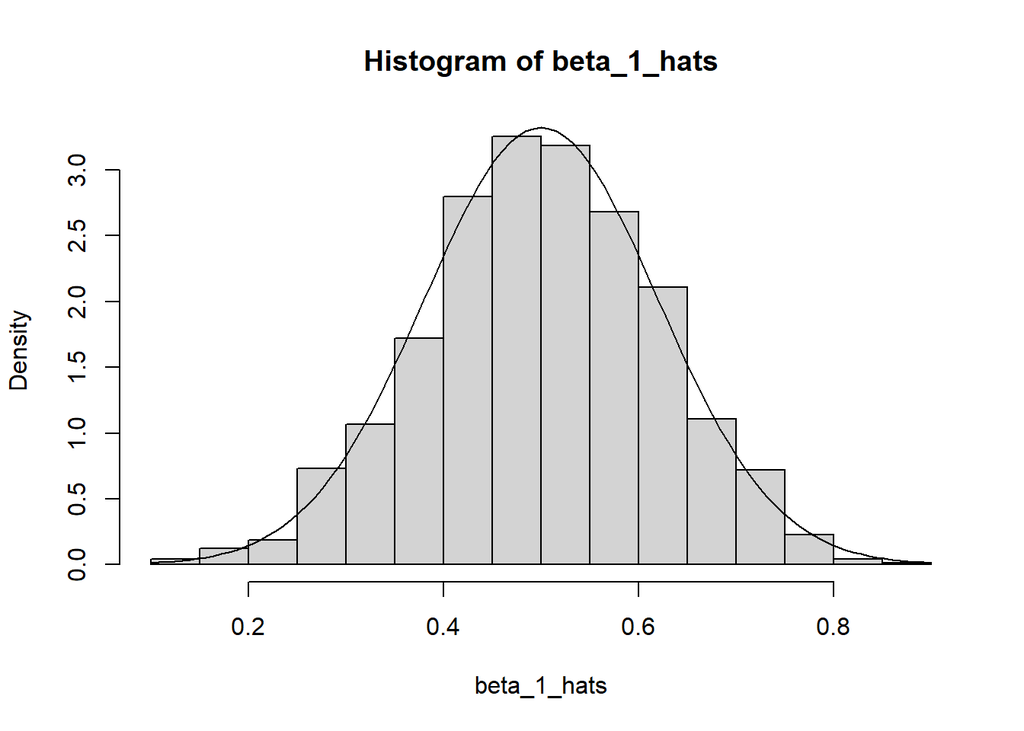

```r
hist(beta_1_hats, prob = TRUE)
var = 25 / Sxx
curve(dnorm(x, mean = 0.5, sd = sqrt(var)), add = TRUE)
```

**(k)**

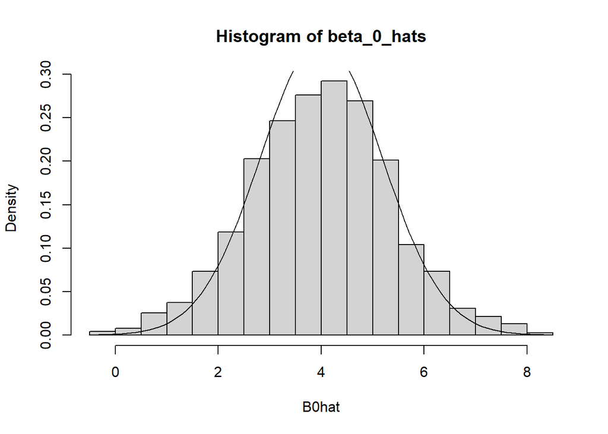

```r
hist(beta_0_hats, prob = TRUE, breaks = 30, xlab = "B0hat")
var_beta_0_hat = 5 * sqrt((1 / 50) + (mean(x) ^ 2 / Sxx))
curve(dnorm(x, mean = 4, sd = sqrt(var_beta_0_hat)), add = TRUE)
```

## Exercise 5 (Simulating Confidence Intervals)

**(a)**

```r
uin = 673856275
set.seed(uin)
n = 20
x = seq(-5, 5, length = n)
beta_0_hats = rep(0, 2000);
se = rep(0, 2000);

lower_90 = rep(0, 2000);
upper_90 = rep(0, 2000);
Sxx = sum((x - mean(x)) ^ 2);
crit_val = qt(0.95, df = n - 2)


for (i in 1:2000) {
  eps = rnorm(20, mean = 0, sd = 4)
  y   = 1 + 3 * x + eps

  sim_model = lm(y ~ x)



  beta_0_hats[i] = coef(sim_model)[1];
  # se[i] = coef(sim_model)[2];
  se[i] = summary(sim_model)$sigma;
  # se[i] = summary(sim_model)$coefficient[1,2]

}
```

**(b)**

```r
for (i in 1:2000) {


  SE = se[i] * sqrt((1/n) + (mean(x)^2/Sxx));
  margin = crit_val * SE;
  lower_90[i] = beta_0_hats[i] - margin;
  upper_90[i] = beta_0_hats[i] + margin;

}
```

**(c)**

```r
sum = 0;
for (i in 1:2000)
{
  if ( lower_90[i]< 1 && upper_90[i] > 1)
    sum = sum +1;
}
# sum
ans= sum / 2000;
ans
```

```
## [1] 0.893
```

**(d)**

```r
sum = 0;
for (i in 1:2000)
{
  if ( lower_90[i]< 0 && upper_90[i] > 0)
    sum = sum +1;
}
# sum
ans= sum / 2000;
1 - ans
```

```
## [1] 0.2885
```

**(e)**

```r
lower_99 = rep(0, 2000);
upper_99 = rep(0, 2000);

crit_vale = qt(0.99, df = n - 2)


for (i in 1:2000) {


  SE = se[i] * sqrt((1/n) + (mean(x)^2/Sxx));
  margin = crit_vale * SE;
  lower_99[i] = beta_0_hats[i] - margin;
  upper_99[i] = beta_0_hats[i] + margin;

}
```

**(f)**

```r
sum = 0;
for (i in 1:2000)
{
  if ( lower_99[i]< 1 && upper_99[i] > 1)
    sum = sum +1;
}
# sum
ans= sum / 2000;
ans
```

```
## [1] 0.981
```

**(f)**

```r
sum = 0;
for (i in 1:2000)
{
  if ( lower_99[i]< 0 && upper_99[i] > 0)
    sum = sum +1;
}
# sum
ans= sum / 2000;
1 - ans
```

```
## [1] 0.115
```